# Homework 3

Zeyi Han, Shubhi Sharma, Maggie Swift

2/10/2020

*Exercise 1.* Is the infection rate estimated to be higher for survivors or for those that die? How are these two distributions affected by the underlying prevalence of infection, $\theta$?

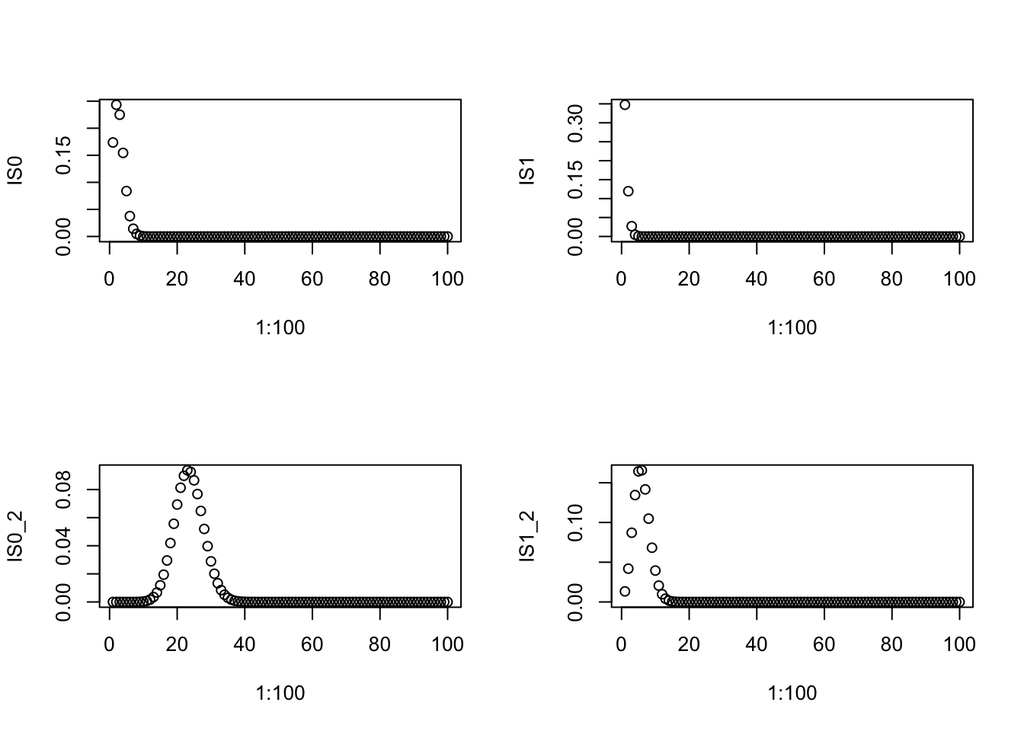

```r
n <- 100
pi0 <- 0.8  #[S|I=1]
pi1 <- 0.2   #[S|I=0]
theta <- 0.03   # new infected

par(mfrow = c(2,2))
IS0 <- dbinom(1:n, 100, (1-pi0)*theta/((1-pi0)*(1-theta)+ (1-pi1)*theta))
plot(1:100, IS0)

IS1 <- dbinom(1:n, 100, pi1*theta/(pi0*(1-theta)+ pi*theta))
plot(1:100, IS1)

theta <- 0.8
IS0_2 <- dbinom(1:n, 100, (1-pi0)*theta/((1-pi0)*(1-theta)+ (1-pi1)*theta))
plot(1:100, IS0_2)

IS1_2 <- dbinom(1:n, 100, pi1*theta/(pi0*(1-theta)+ pi*theta))
plot(1:100, IS1_2)
```

*Exercise 2.* The variance in beta distribution decreases as the value of parameter b increases. Change parameter values to demonstrate this with a plot. Then compare the mean and variance (see Appendix) from the moments for the binomial and beta-binomial.

Variance decreases with increasing beta.

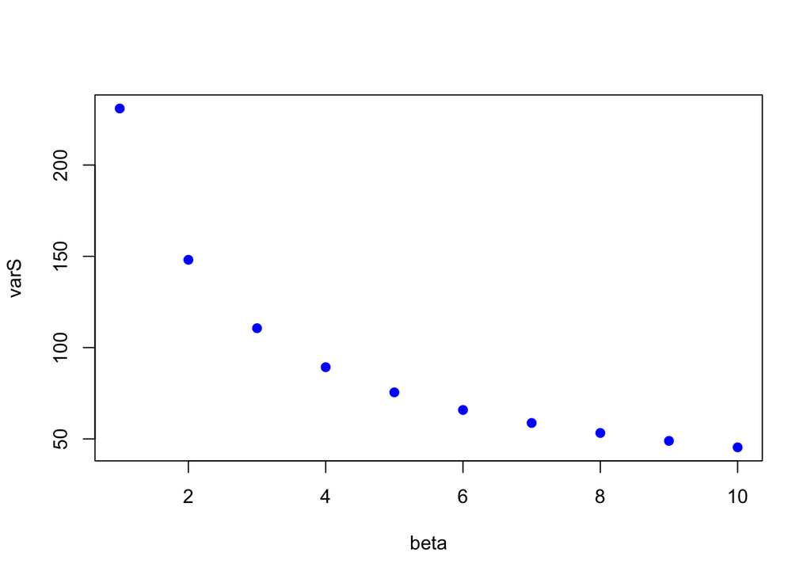

```r
# Params
m  <- 50                      # no. at risk
S  <- 0:m
pi <- .35                     # survival Pr
beta <- 1:10

meanS <- lapply(beta, function(x) sum( S*dbetaBinom(S, m, mu=pi,b=x)))
varS  <- lapply(1:length(beta), function(x) sum( (S-meanS[[x]])^2*dbetaBinom(S, m, mu=pi,b=beta[x]) ))
plot(beta, varS, pch=19, col='blue')
```

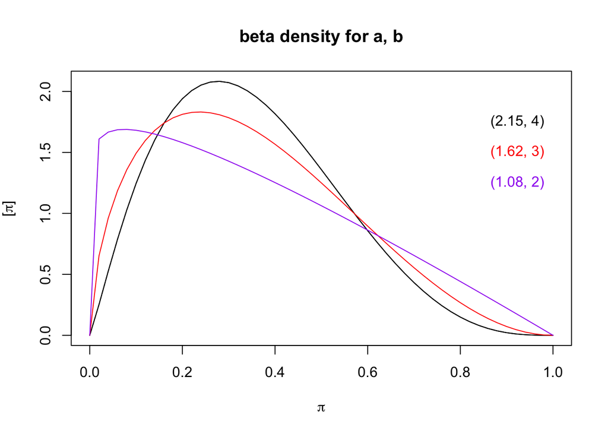

```r
# Initialize plot
b  <- 4:2                     # beta parameters
a  <- signif(b[1]/(1/pi - 1),3)  # 2nd beta parameter to give mean value = pi
plot(S/m, dbeta(S/m, a, b[1]), xlab=expression( pi ),
     ylab=expression( paste("[", pi, "]") ), type='l')

title('beta density for a, b')
cols <- c('black', 'red', 'purple')
locs <- c(1.75, 1.5, 1.25)
for (i in 1:length(b)) {
  a  <- signif(b[i]/(1/pi - 1),3)  # 2nd beta parameter to give mean value = pi
  lines(S/m, dbeta(S/m, a, b[i]), col=cols[i])
  ptext <- paste( "(", a, ", ", b[i], ")", sep="")
  text(1,locs[i], ptext,  pos=2, col=cols[i])
}
```

Comparing Variances:

```r
# beta-binomial
m.bb <- sum( S*dbetaBinom(S, m, mu=pi,b=b) )
v.bb  <- sum( (S - m.bb)^2*dbetaBinom(S, m, mu=pi,b=b) )
# binomial
m.binom <- m * pi
v.binom <- m * pi * (1-pi)
# beta
b <- b[1]
m.beta <- (a / (a + b))
v.beta <- (a * b) / ( (a + b)^2 * (a + b + 1))

df <- data.frame(mean=c(m.bb, m.binom, m.beta), var=c(v.bb, v.binom, v.beta))
rownames(df) <- c('beta-binomial', 'binomial', 'beta')
knitr::kable(df)
```

|  | mean | var |
| --- | --- | --- |
| beta-binomial | 17.5087078 | 113.3734782 |
| binomial | 17.5000000 | 11.3750000 |
| beta | 0.2125984 | 0.0275329 |

*Exercise 3.* I observe $D$ and $S$, and I know $\phi$ from previous studies. What is the probability of an observation $[D=1,S=1]$. (Hint: use total probability on $[D,I,S]$). Now write down the posterior distribution for a parameter that represents the product of infection and survival $\rho=\theta\pi_1$ given observations and known detection probability, i.e., $[\rho|D=1,S=1,\phi]$.

$[S=1] = \pi_0(1-\theta) + \pi_1\theta$

$[D=1] = [D=1|I][I] = [D=1|I=0][I=0] + [D=1|I=1][I=1] = [D=1|I=1][I=1] = \phi\theta$

Because $D$ and $S$ are independent, $[D=1, S=1]=[D=1][S=1]=(\phi\theta)\cdot(\pi_0(1-\theta)+\pi_1\theta)$

$\rho = \theta\pi_1$

$[\rho|D=1,S=1,\phi]\propto[D=1, S=1|\rho][I] = [D=1, S=1|\rho][\phi][\pi_1]$, where the prior is $\phi\pi_1$.

*Exercise 4.* Write a function to determine the posterior estimate of the mean for a normal likelihood, normal prior distribution, and known variance $\sigma^2$. You will need to generate a sample, supply a prior mean and variance, determine the posterior mean and variance, and plot.

```r
posteriorSample <- function(samples, llMean, priorMean, llVar, priorVar, varReturn= 'posterior'){
  #parameters from user
  n = samples
  mu = llMean
  mu0 = priorMean
  sigma = llVar
  tau = priorVar

  set.seed(101)

  #sampling
  y <- rnorm(n, mu, sigma)
  ybar <- mean(y)

  # pull prior and posterior
  prior <- rnorm(n, mu0, tau)
  sigmaN <- n/sigma^2 + 1/tau^2
  muN <- ((n*ybar)/sigma^2 + mu0/tau^2)/sigmaN
  posterior <- rnorm(n, muN, sigmaN)

  if(varReturn == 'posterior'){ return(posterior) }
  if(varReturn == 'prior'){ return(prior) }
  if(varReturn == 'likelihood'){ return(y) }
}

generateAll <- function(n, mu, m0, sigma, tau) {
  posterior <- posteriorSample(samples = n, llMean = mu,
                             priorMean = mu0, llVar = sigma,
                             priorVar = tau)
  prior <-  posteriorSample(samples = n, llMean = mu,
                             priorMean = mu0, llVar = sigma,
                             priorVar = tau, varReturn = 'prior')
  likelihood <- posteriorSample(samples = n, llMean = mu,
                             priorMean = mu0, llVar = sigma,
                             priorVar = tau, varReturn = 'likelihood')
  plot(density(prior), col = 'blue', xlab = "x", ylab = "p(x)",
       main = "Normal-normal posterior", ylim= c(0, 0.06))
  lines(density(likelihood), col = 'black')
  lines(density(posterior), col = 'red')
  legend('topright', legend = c('likelihood', 'posterior', 'prior'),
         col = c('black', 'red', 'blue'), lty = c(1, 1, 1))
}
```

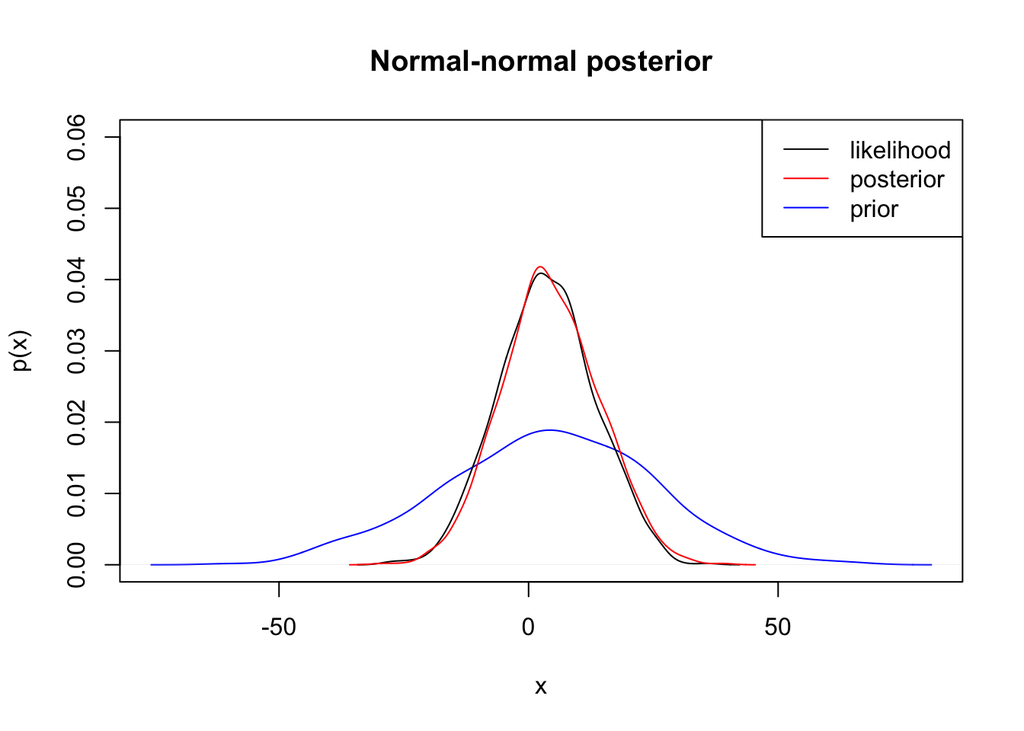

```r
n <- 1000 # number of samples
mu <- 4 # sample mean
mu0 <- 4 # prior mean
sigma <- 10
tau <- 20

generateAll(n, mu, m0, sigma, tau)
```

*Exercise 5.* Obtain the posterior mean and variance for regression parameters for a simulated data set.

For 1000 samples, $Y|\mu \sim N(\mu, \sigma^2)$. Setting $\mu = 4, \sigma = 10$, $\mu \sim N(\mu_0, \tau^2)$. Setting $\mu_0= 4, \tau = 20$, we get posterior mean $= 4.04$ and posterior variance $= 100.5$.

```r
generateTables <- function(n, p, sigma) {
  X <- matrix(rnorm(p*n, 7, 10), n, p )
  X[, 1] <- 1

  beta <- matrix(rnorm(p, 4, 9), p, 1 )
  y <- matrix(rnorm(n, 5, 8), n, 1)
  b <- matrix(rnorm(p, 6, 9), p, 1)
  B <- diag(x = 20, nrow = p, ncol = p)
  V = solve((1/sigma^2) * t(X)%*%X + solve(B))
  v = (1/sigma^2)*t(X)%*%y + solve(B)%*% b

  Vv = V%*%v
  betas = c('beta1', 'beta2', 'beta3', 'beta4', 'beta5')
  df <- data.frame(cbind(V, Vv))
  row.names(df) = betas
  names(df) <- c(betas, 'mean')
  knitr::kable(df, caption="Means and Covariances") #covariance
}
```

```r
# MAIN
n = 1000
p = 5
sigma = 10
generateTables(n,p,sigma)
```

Means and Covariances

|  | beta1 | beta2 | beta3 | beta4 | beta5 | mean |
| --- | --- | --- | --- | --- | --- | --- |
| beta1 | 0.3009515 | -0.0072986 | -0.0066257 | -0.0076245 | -0.0068617 | 4.6004996 |
| beta2 | -0.0072986 | 0.0009963 | 0.0000001 | 0.0000298 | -0.0000178 | 0.0339050 |
| beta3 | -0.0066257 | 0.0000001 | 0.0009887 | -0.0000213 | -0.0000151 | 0.0202347 |
| beta4 | -0.0076245 | 0.0000298 | -0.0000213 | 0.0010565 | 0.0000018 | -0.0285126 |
| beta5 | -0.0068617 | -0.0000178 | -0.0000151 | 0.0000018 | 0.0010110 | 0.0107737 |